# Uber Analysis

Dory Munoko

12/20/2021

1. Load Packages

```r
library(ggplot2)
library(ggthemes)
library(lubridate)
library(dplyr)
library(tidyr)
library(DT)
library(scales)
```

2. Creating vector of colors to be implemented in our plots

```r
colors = c("red", "grey", "green", "black", "yellow", "blue", "purple")
```

3. Reading the Data into their designated variables

```r
apr <- read.csv("/Users/ruthb/Desktop/Dory's Projects/Uber Project/Uber-dataset/uber-raw-data-apr14.csv")
may <- read.csv("/Users/ruthb/Desktop/Dory's Projects/Uber Project/Uber-dataset/uber-raw-data-may14.csv")
jun <- read.csv("/Users/ruthb/Desktop/Dory's Projects/Uber Project/Uber-dataset/uber-raw-data-jun14.csv")
jul <- read.csv("/Users/ruthb/Desktop/Dory's Projects/Uber Project/Uber-dataset/uber-raw-data-jul14.csv")
aug <- read.csv("/Users/ruthb/Desktop/Dory's Projects/Uber Project/Uber-dataset/uber-raw-data-aug14.csv")
sep <- read.csv("/Users/ruthb/Desktop/Dory's Projects/Uber Project/Uber-dataset/uber-raw-data-sep14.csv")
```

4. Combine all of this data into a single data frame called ‘data’

```r
data <- rbind(apr, may, jun, jul, aug, sep)
View(data)
```

5. Formatting of Date.Time column

```r
data$Date.Time <- as.POSIXct(data$Date.Time, format = "%m/%d/%Y %H:%M:%S")
data$Time <- format(as.POSIXct(data$Date.Time, format = "%m/%d/%Y %H:%M:%S"), format="%H:%M:%S")
data$Date.Time <- ymd_hms(data$Date.Time)
data$day <- factor(day(data$Date.Time))
data$month <- factor(month(data$Date.Time, label = TRUE))
data$year <- factor(year(data$Date.Time))
data$dayofweek <- factor(wday(data$Date.Time, label = TRUE))
```

6. Create factors of time objects like day, month, year etc.

```r
data$hour <- factor(hour(hms(data$Time)))
data$minute <- factor(minute(hms(data$Time)))
data$second <- factor(second(hms(data$Time)))
```

7. Plotting the trips by the hours in a day. We observe that the number of trips are higher in the evening around 5:00 and 6:00 PM.

```r
hour <- data %>%
        group_by(hour) %>%
        dplyr::summarize(Total = n())
datatable(hour)
```

|  | hour | Total |
| --- | --- | --- |
| 1 | 0 | 103836 |
| 2 | 1 | 67227 |
| 3 | 2 | 45865 |
| 4 | 3 | 48287 |
| 5 | 4 | 55230 |
| 6 | 5 | 83939 |
| 7 | 6 | 143213 |
| 8 | 7 | 193094 |
| 9 | 8 | 190504 |
| 10 | 9 | 159967 |

[output cut: 14 more lines]

8. We will use dplyr to aggregate our data.

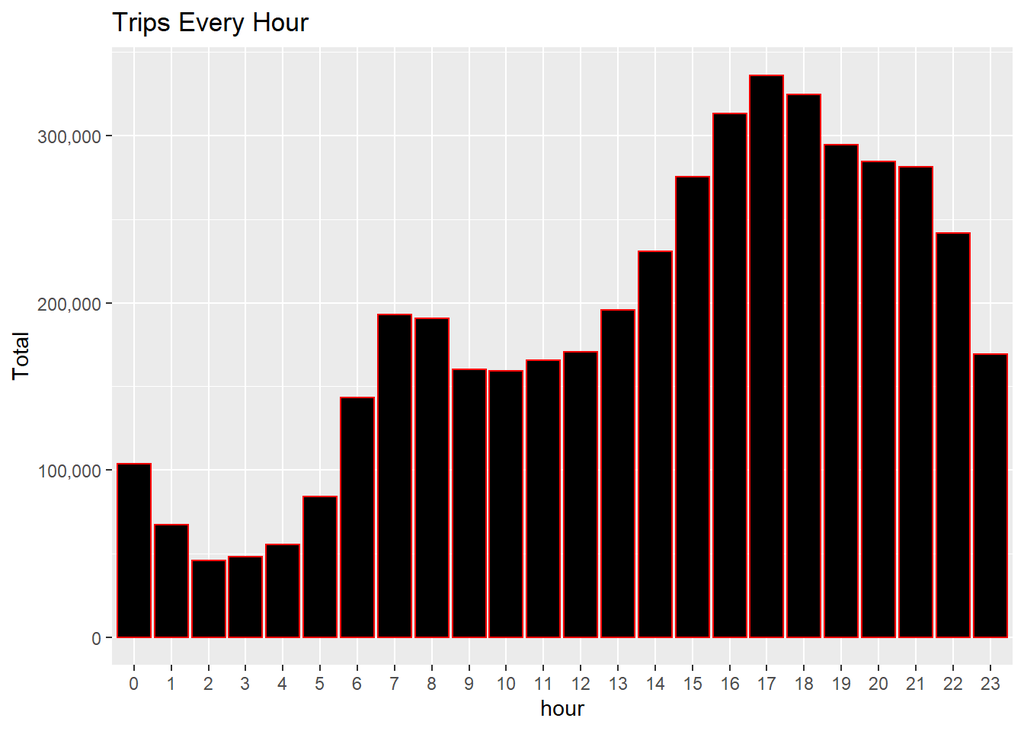

```r
ggplot(hour, aes(hour, Total)) +
        geom_bar( stat = "identity", fill = "black", color = "red") +
           ggtitle("Trips Every Hour") +
            theme(legend.position = "none") +
            scale_y_continuous(labels = comma)
```

```r
month_hour <- data %>%
          group_by(month, hour) %>%
             dplyr::summarize(Total = n())
```

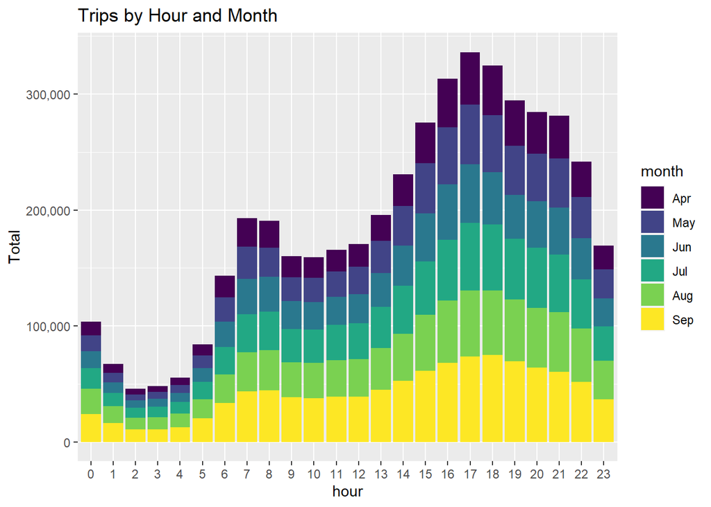

```r
ggplot(month_hour, aes(hour, Total, fill = month)) +
       geom_bar( stat = "identity") +
          ggtitle("Trips by Hour and Month") +
           scale_y_continuous(labels = comma)
```

9. Plotting data by trips during every day of the month. We observe that 30th of the month had the highest trips in the year which is mostly contributed by the month of April.

```r
day <- data %>%
          group_by(day) %>%
             dplyr::summarize(Total = n())
datatable(day)
```

|  | day | Total |
| --- | --- | --- |
| 1 | 1 | 127430 |
| 2 | 2 | 143201 |
| 3 | 3 | 142983 |
| 4 | 4 | 140923 |
| 5 | 5 | 147054 |
| 6 | 6 | 139886 |
| 7 | 7 | 143503 |
| 8 | 8 | 145984 |
| 9 | 9 | 155135 |
| 10 | 10 | 152500 |

[output cut: 21 more lines]

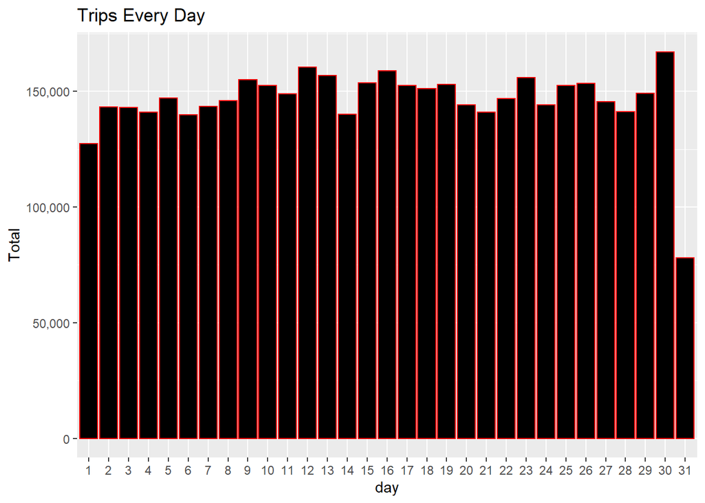

```r
ggplot(day, aes(day, Total)) +
        geom_bar( stat = "identity", fill = "black", color = "red") +
           ggtitle("Trips Every Day") +
            theme(legend.position = "none") +
            scale_y_continuous(labels = comma)
```

```r
day_month <- data %>%
         group_by(month, day) %>%
             dplyr::summarize(Total = n())
```

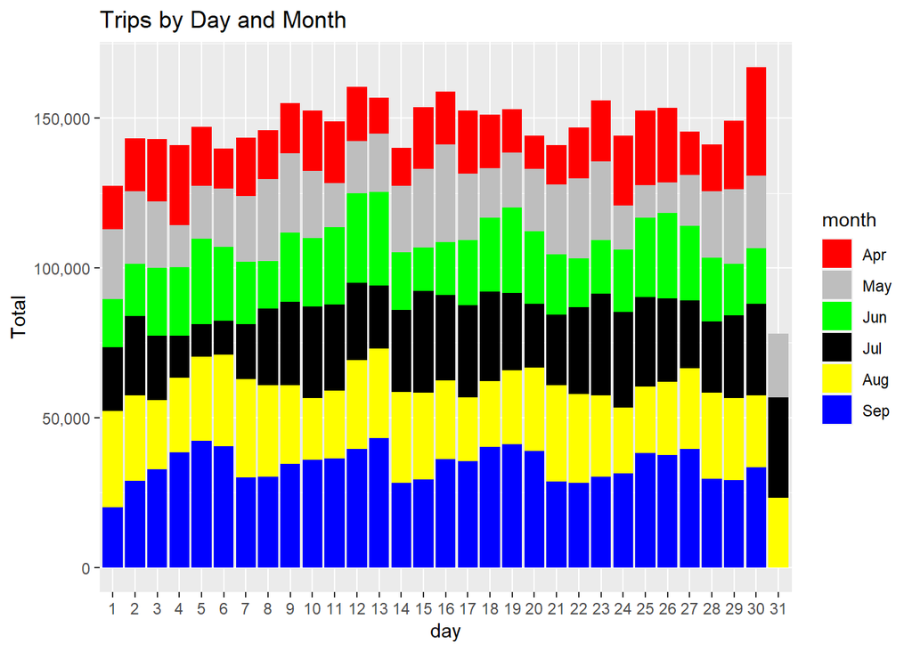

```r
ggplot(day_month, aes(day, Total, fill = month)) +
        geom_bar( stat = "identity") +
           ggtitle("Trips by Day and Month") +
            scale_y_continuous(labels = comma)+
            scale_fill_manual(values = colors)
```

10. Number of trips during months in a year We observe that most trips were made during the month of September.

```r
month <- data %>%
         group_by(month) %>%
         dplyr::summarize(Total = n())
datatable(month)
```

|  | month | Total |
| --- | --- | --- |
| 1 | Apr | 564516 |
| 2 | May | 652435 |
| 3 | Jun | 663844 |
| 4 | Jul | 796121 |
| 5 | Aug | 829275 |
| 6 | Sep | 1028136 |

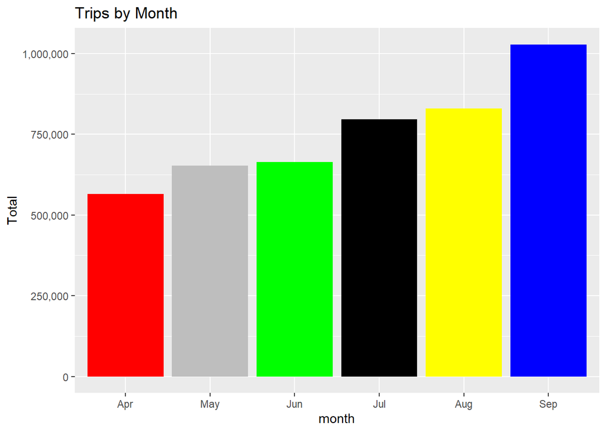

```r
ggplot(month, aes(month, Total, fill = month)) +
        geom_bar( stat = "identity") +
           ggtitle("Trips by Month") +
            theme(legend.position = "none") +
            scale_y_continuous(labels = comma) +
            scale_fill_manual(values = colors)
```

```r
month_weekday <- data %>%
         group_by(month, dayofweek) %>%
             dplyr::summarize(Total = n())
```

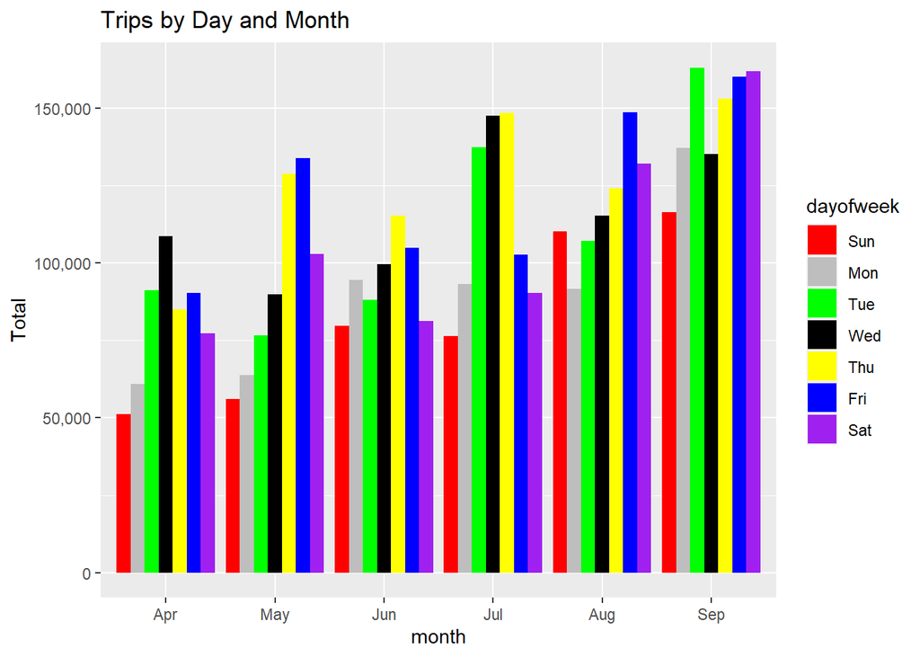

```r
ggplot(month_weekday, aes(month, Total, fill = dayofweek)) +
       geom_bar( stat = "identity", position = "dodge") +
          ggtitle("Trips by Day and Month") +
           scale_y_continuous(labels = comma) +
           scale_fill_manual(values = colors)
```

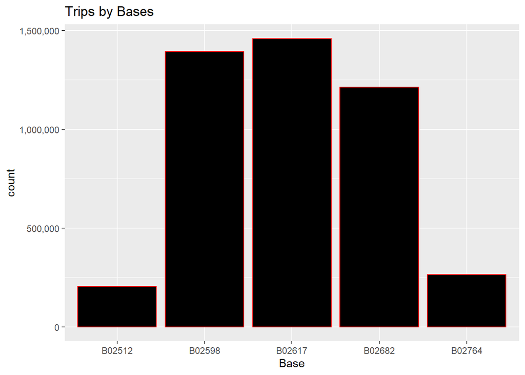

```r
ggplot(data, aes(Base)) +
 geom_bar(fill = "black", color = "red") +
 scale_y_continuous(labels = comma) +
 ggtitle("Trips by Bases")
```

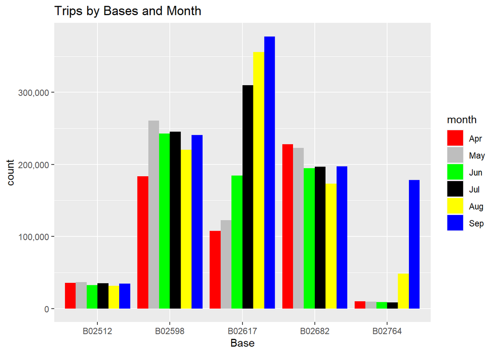

```r
ggplot(data, aes(Base, fill = month)) +
 geom_bar(position = "dodge") +
 scale_y_continuous(labels = comma) +
 ggtitle("Trips by Bases and Month") +
 scale_fill_manual(values = colors)
```

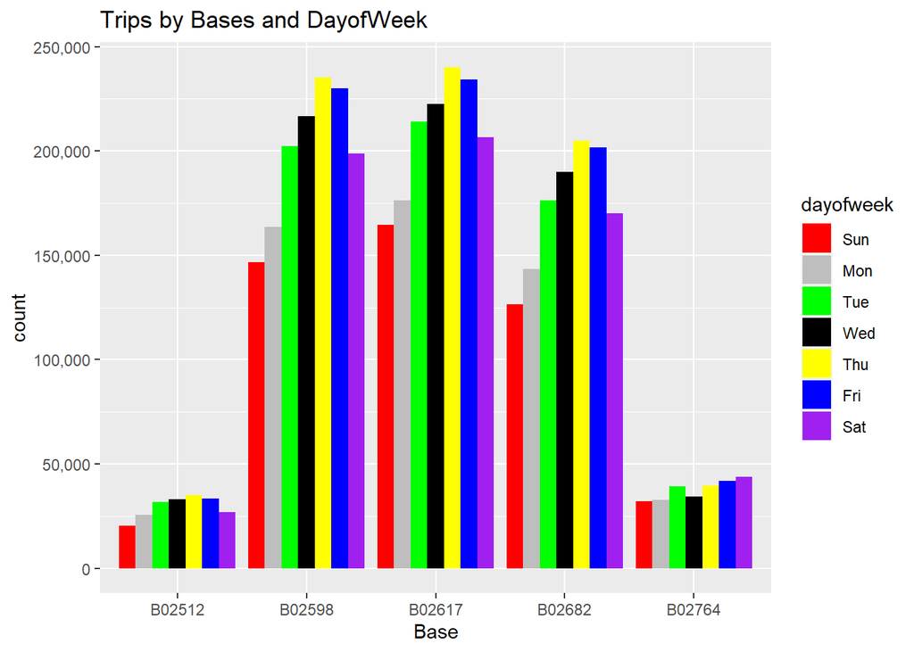

```r
ggplot(data, aes(Base, fill = dayofweek)) +
 geom_bar(position = "dodge") +
 scale_y_continuous(labels = comma) +
 ggtitle("Trips by Bases and DayofWeek") +
 scale_fill_manual(values = colors)
```

12. Creating a Heatmap visualization of day, hour and month First, we will plot Heatmap by Hour and Day. Second, we will plot Heatmap by Month and Day. Third, a Heatmap by Month and Day of the Week. Fourth, a Heatmap that delineates Month and Bases. Finally, we will plot the heatmap, by bases and day of the week.

```r
day_hour <- data %>%
         group_by(day, hour) %>%
            dplyr::summarize(Total = n())
datatable(day_hour)
```

|  | day | hour | Total |
| --- | --- | --- | --- |
| 1 | 1 | 0 | 3247 |
| 2 | 1 | 1 | 1982 |
| 3 | 1 | 2 | 1284 |
| 4 | 1 | 3 | 1331 |
| 5 | 1 | 4 | 1458 |
| 6 | 1 | 5 | 2171 |
| 7 | 1 | 6 | 3717 |
| 8 | 1 | 7 | 5470 |
| 9 | 1 | 8 | 5376 |
| 10 | 1 | 9 | 4688 |

[output cut: 734 more lines]

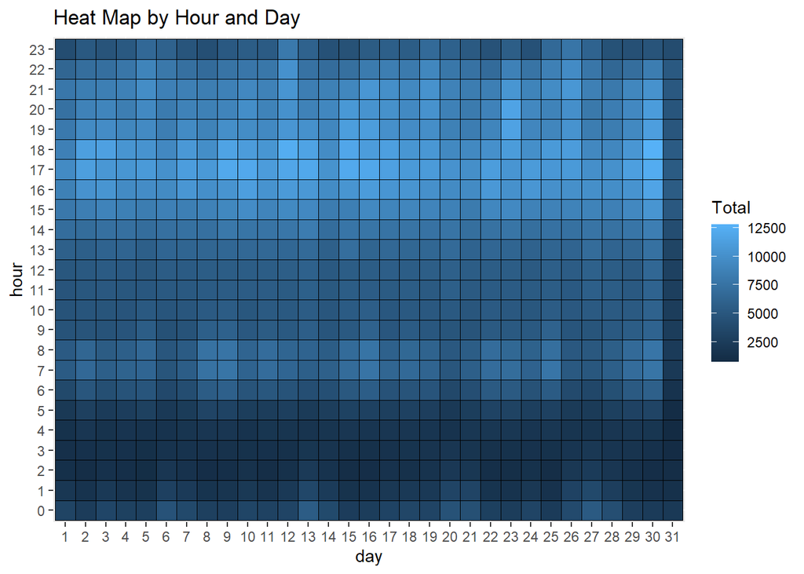

```r
ggplot(day_hour, aes(day, hour, fill = Total)) +
            geom_tile(color = "black") +
              ggtitle("Heat Map by Hour and Day")
```

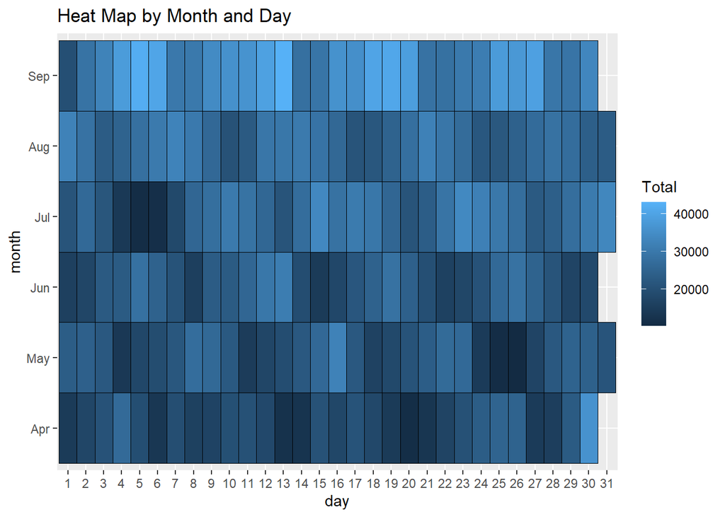

```r
ggplot(day_month, aes(day, month, fill = Total)) +
            geom_tile(color = "black") +
              ggtitle("Heat Map by Month and Day")
```

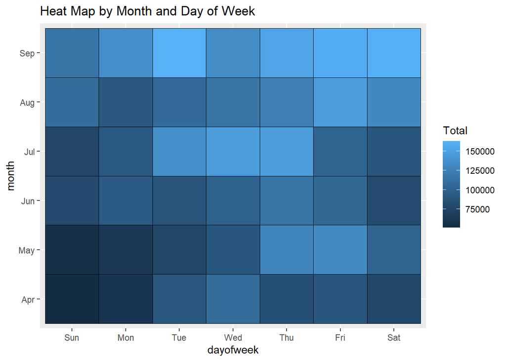

```r
ggplot(month_weekday, aes(dayofweek, month, fill = Total)) +
            geom_tile(color = "black") +
              ggtitle("Heat Map by Month and Day of Week")
```

```r
month_base <-  data %>%
               group_by(Base, month) %>%
               dplyr::summarize(Total = n())
dayofweek_bases <- data %>%
                   group_by(Base, dayofweek) %>%
                   dplyr::summarize(Total = n())
```

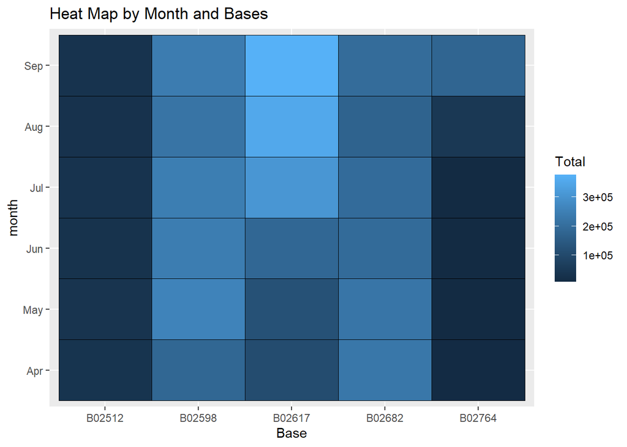

```r
ggplot(month_base, aes(Base, month, fill = Total)) +
            geom_tile(color = "black") +
              ggtitle("Heat Map by Month and Bases")
```

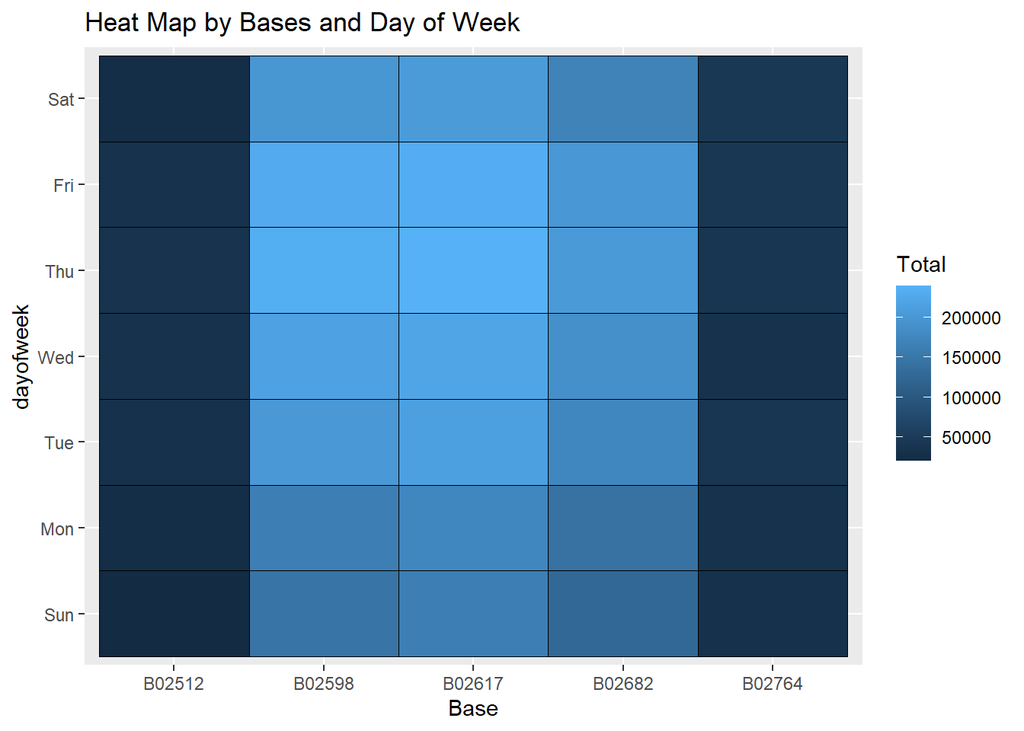

```r
ggplot(dayofweek_bases, aes(Base, dayofweek, fill = Total)) +
            geom_tile(color = "black") +
              ggtitle("Heat Map by Bases and Day of Week")
```

13. Creating a map visualization of rides in New York In the final section, we will visualize the rides in New York city by creating a geo-plot that will help us to visualize the rides during 2014 (Apr–Sep) and by the bases in the same period.

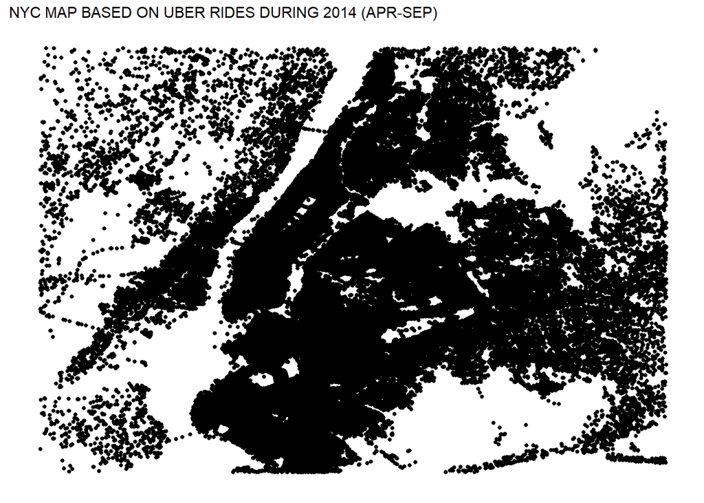

```r
min_lat <- 40.5774
max_lat <- 40.9176
min_long <- -74.15
max_long <- -73.7004

ggplot(data, aes(x=Lon, y=Lat)) +
  geom_point(size=1, color = "black") +
     scale_x_continuous(limits=c(min_long, max_long)) +
      scale_y_continuous(limits=c(min_lat, max_lat)) +
        theme_map() +
           ggtitle("NYC MAP BASED ON UBER RIDES DURING 2014 (APR-SEP)")
```

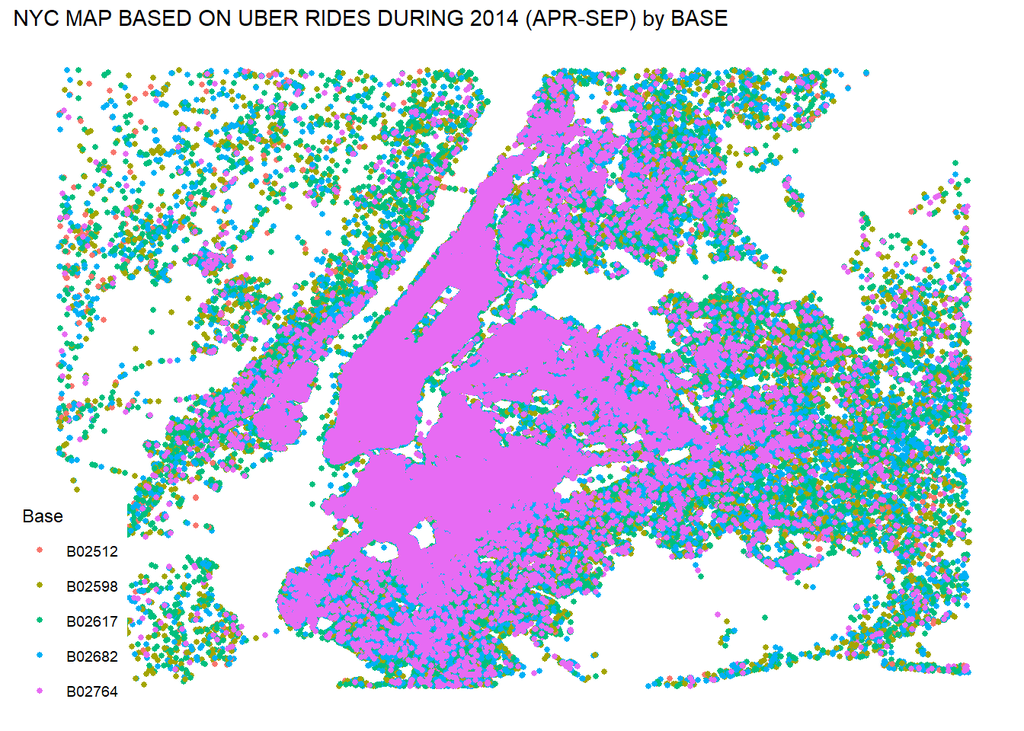

```r
ggplot(data, aes(x=Lon, y=Lat, color = Base)) +
  geom_point(size=1) +
     scale_x_continuous(limits=c(min_long, max_long)) +
      scale_y_continuous(limits=c(min_lat, max_lat)) +
       theme_map() +
          ggtitle("NYC MAP BASED ON UBER RIDES DURING 2014 (APR-SEP) by BASE")
```